# Exercise 5

Mahes Muniandy

24 February 2017

## Dimension Reduction

This week, we learnt how to do dimension reduction.

## Summary of data

```
## [1] 154   8
```

```
## 'data.frame':    154 obs. of  8 variables:
##  $ ï..gii_FM_edu_rat: num  1.007 0.997 0.983 0.989 0.969 ...
##  $ gii_FM_work_rat  : num  0.891 0.819 0.825 0.884 0.829 ...
##  $ exp_edu          : num  17.5 20.2 15.8 18.7 17.9 16.5 18.6 16.5 15.9 19.2 ...
##  $ life_exp         : num  81.6 82.4 83 80.2 81.6 80.9 80.9 79.1 82 81.8 ...
##  $ GNI              : int  64992 42261 56431 44025 45435 43919 39568 52947 42155 32689 ...
##  $ mat_mor_rat      : int  4 6 6 5 6 7 9 28 11 8 ...
##  $ adol_birth_rat   : num  7.8 12.1 1.9 5.1 6.2 3.8 8.2 31 14.5 25.3 ...
##  $ fem_parlimen     : num  39.6 30.5 28.5 38 36.9 36.9 19.9 19.4 28.2 31.4 ...
```

There are 154 rows and 8 variables:

- gii_FM_edu_rat: ratio of females over males with at least secondary education
- gii_FM_work_rat : ratio of females over males who work
- exp_edu : Expected years of schooling
- life_exp : Life expectancy at birth
- GNI : Gross National Income per capita
- mat_mor_rat : Maternal mortality ratio
- adol_birth_rat : Adolescent birth rate
- fem_parlimen : percentage of females in parlimen

## Variable correlation

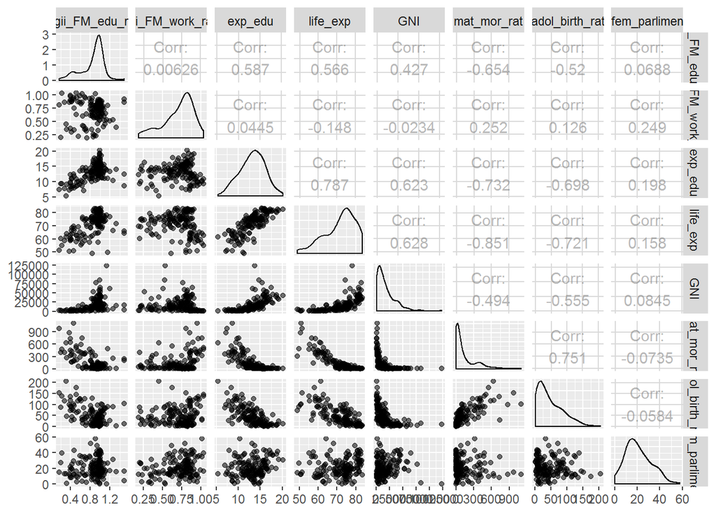

The dataset plot shows that most of the distributions of the variables are not normal.

```
##                   ï..gii_FM_edu_rat gii_FM_work_rat exp_edu life_exp   GNI
## ï..gii_FM_edu_rat              1.00            0.01    0.59     0.57  0.43
## gii_FM_work_rat                0.01            1.00    0.04    -0.15 -0.02
## exp_edu                        0.59            0.04    1.00     0.79  0.62
## life_exp                       0.57           -0.15    0.79     1.00  0.63
## GNI                            0.43           -0.02    0.62     0.63  1.00
## mat_mor_rat                   -0.65            0.25   -0.73    -0.85 -0.49
## adol_birth_rat                -0.52            0.13   -0.70    -0.72 -0.55
## fem_parlimen                   0.07            0.25    0.20     0.16  0.08
##                   mat_mor_rat adol_birth_rat fem_parlimen
## ï..gii_FM_edu_rat       -0.65          -0.52         0.07
## gii_FM_work_rat          0.25           0.13         0.25
## exp_edu                 -0.73          -0.70         0.20
## life_exp                -0.85          -0.72         0.16
## GNI                     -0.49          -0.55         0.08
## mat_mor_rat              1.00           0.75        -0.07
## adol_birth_rat           0.75           1.00        -0.06
## fem_parlimen            -0.07          -0.06         1.00
```

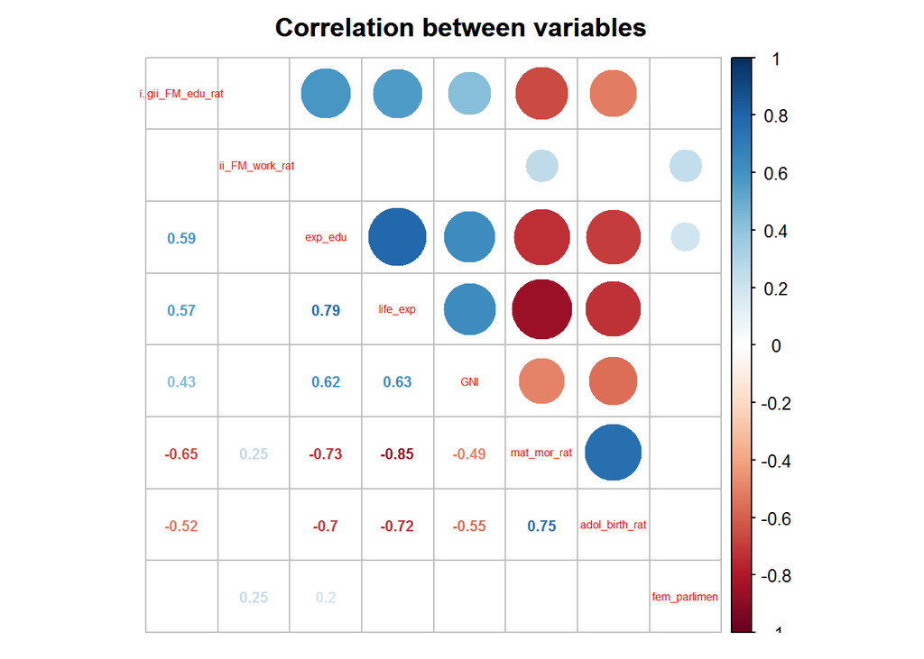

The table above shows the correlations between the variables. The correlation plot below it shows the value of the above correlations with circles: the bigger the circle, the higher the correlation. Only significant (p<0.05) correlations are shown.

There is a high, significant correlation between life expectancy and expected education (0.79) and expected education and GNI (0.62). There is also a high negative correlation between expected education (-0.73) and adolescence birth rate (-0.7). Life expectancy also has a high positive correlation (0.63) with GNI. There is also a high negative correlation between life expectancy and maternal mortality rate (-0.85) and life expectancy and adolescence birth rate (-0.72). There is also a significant correlation between GNI and adolescence birth rate (-0.55) and maternal mortality rate and adolescence birth rate (0.75).

## PCA with unscaled data

```
## Importance of components:
##                              PC1      PC2   PC3   PC4   PC5   PC6    PC7
## Standard deviation     1.857e+04 181.7501 25.27 11.46 3.777 1.567 0.1914
## Proportion of Variance 9.999e-01   0.0001  0.00  0.00 0.000 0.000 0.0000
## Cumulative Proportion  9.999e-01   1.0000  1.00  1.00 1.000 1.000 1.0000
##                           PC8
## Standard deviation     0.1592
## Proportion of Variance 0.0000
## Cumulative Proportion  1.0000
```

```
## PC1 PC2 PC3 PC4 PC5 PC6 PC7 PC8
## 100   0   0   0   0   0   0   0
```

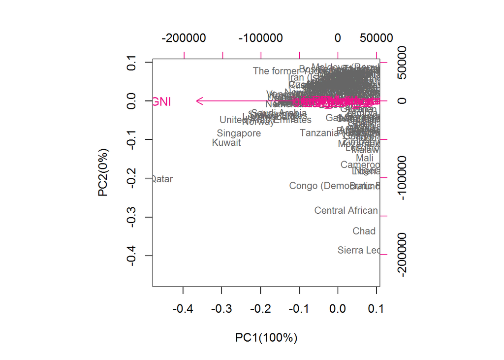

The plot shows that 1 PC is enough to capture almost 100% of the variation in the data. The biplot shows that countries that cluster together have high correlations.

## PCA with scaled data

```
## Importance of components:
##                           PC1    PC2     PC3     PC4     PC5     PC6
## Standard deviation     2.0642 1.1414 0.87702 0.78089 0.66499 0.54362
## Proportion of Variance 0.5326 0.1628 0.09615 0.07622 0.05528 0.03694
## Cumulative Proportion  0.5326 0.6955 0.79163 0.86785 0.92313 0.96007
##                            PC7     PC8
## Standard deviation     0.45969 0.32885
## Proportion of Variance 0.02641 0.01352
## Cumulative Proportion  0.98648 1.00000
```

```
##  PC1  PC2  PC3  PC4  PC5  PC6  PC7  PC8
## 53.3 16.3  9.6  7.6  5.5  3.7  2.6  1.4
```

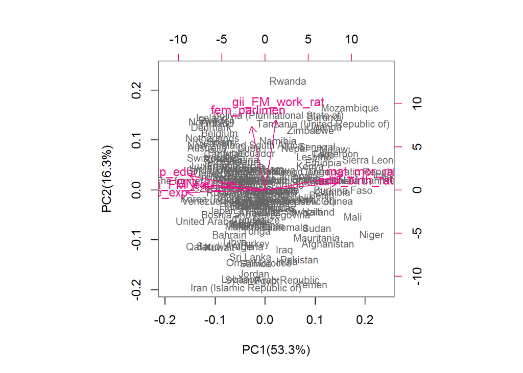

The scaled data shows that females in parlimen are not highly correlated with maternal mortality rate as well as adoscelence birth rate. There is also negative correlation between expected education and life expectancy with maternal mortality ratio aand adolexcence birth rate. The countries that are closer together are more correlated.